# Ch1_Hurdle SWA & VEG ~ BeaverDam

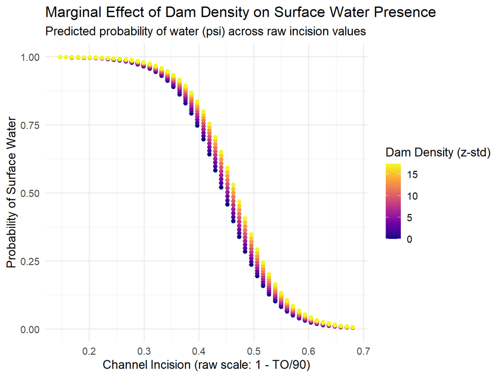

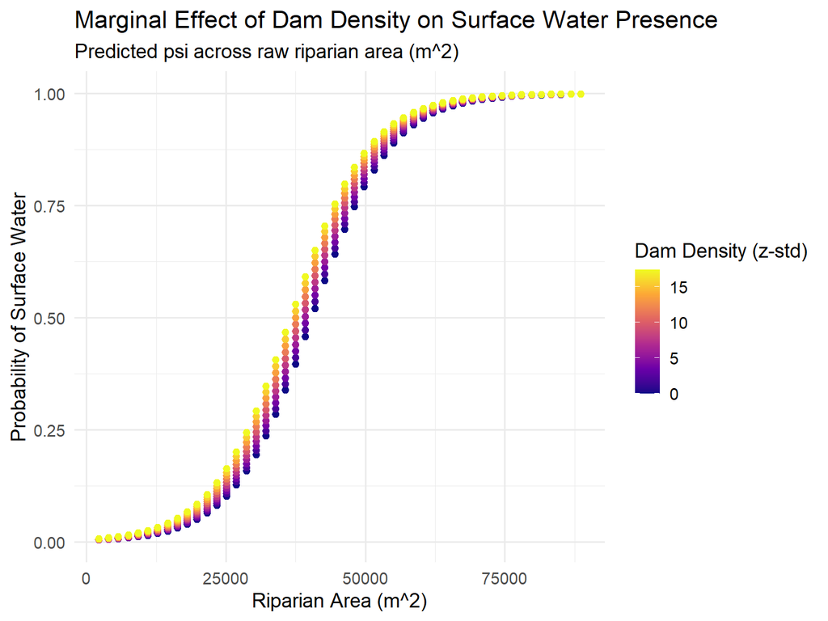

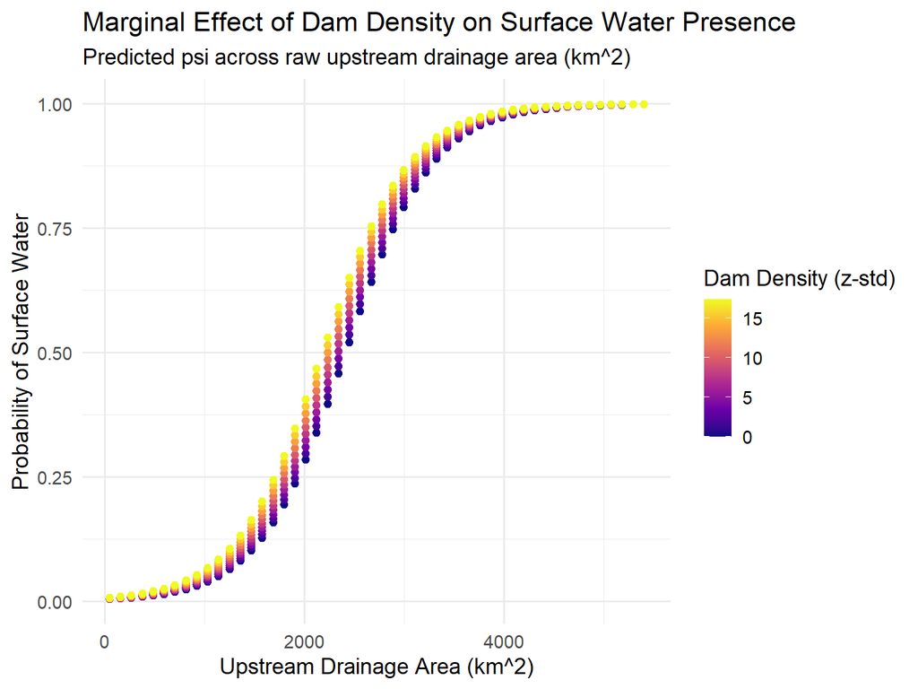

**Partial dependence plots**

Constrain PDP to empirical ranges for SWA and target covariates

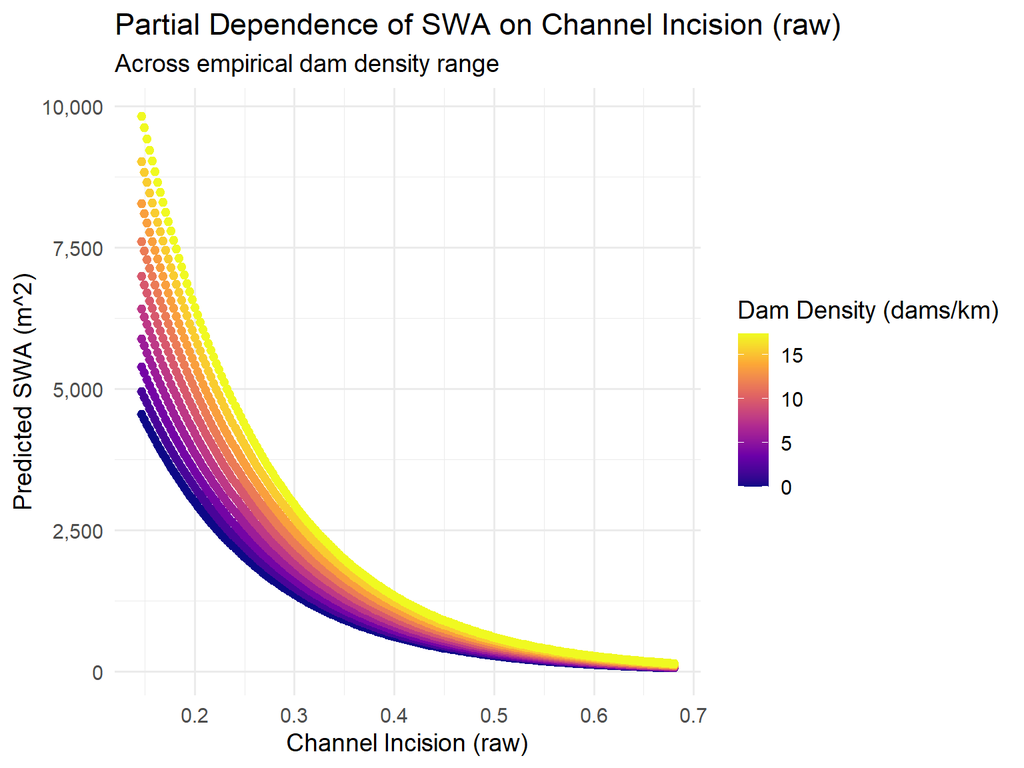

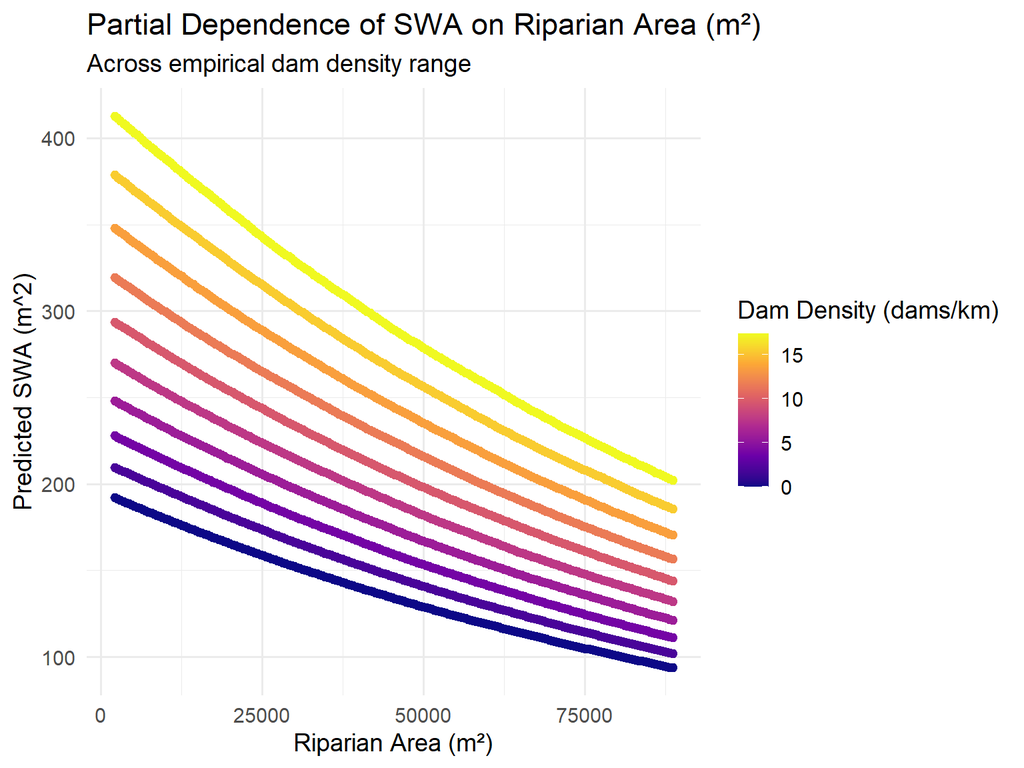

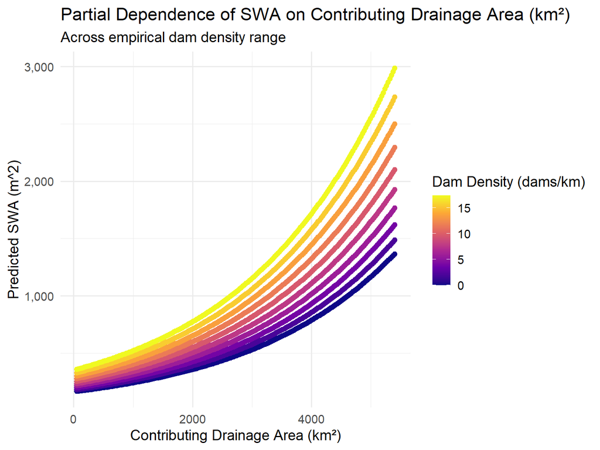

## —-

## —-

## —-

## —-

## —-

## —-

## —-

## —-

## —-

## —-

## —-

## —-

## —-

## —-

## —-

## —-

## —-

## —-

## —-

## —-

```
This section explores late summner vegetation (veg area (m^2) and NDVI) in
relation to beaver dam presence.

Uses hurdle model with nested random slopes for beaver dam effect to allow
for stream, year,
and sampleEvent to cause deviation from the global mean beaver effect.

Pt1: Surface water presence/absence; logistic regression
Pt2: Surface water amount; log(Normal) regression

Uses log(SWA) for AOI all years. Adjust priors accordingly...
```

## —-

## **Hurdle HGLMM**

```
sink("HGLMM_hurdle_damPresence.jags")

cat("
model{
  # NEED priors and hyperpriors first so that downstream nodes can be estimated

  ##########################################################################

  # HYPERPRIORS FOR SW PRESENCE (1/2 Normal on SDs):

  sigma_zeta_stream  ~ dnorm(0,1) T(0,)
  tau_zeta_stream    <- pow(sigma_zeta_stream, -2)

  sigma_zeta_year    ~ dnorm(0,1) T(0,)
  tau_zeta_year      <- pow(sigma_zeta_year, -2)

  sigma_zeta_event   ~ dnorm(0,1) T(0,)
  tau_zeta_event     <- pow(sigma_zeta_event, -2)

  sigma_iota_stream  ~ dnorm(0,1) T(0,)
  tau_iota_stream    <- pow(sigma_iota_stream, -2)

  sigma_iota_event   ~ dnorm(0,1) T(0,)
  tau_iota_event     <- pow(sigma_iota_event, -2)

  sigma_iota_cluster ~ dnorm(0,1) T(0,)
  tau_iota_cluster   <- pow(sigma_iota_cluster, -2)

  ##########################################################################
  # HYPERPRIORS FOR SW AMOUNT (1/2 Normal on SDs):

  sigma              ~ dnorm(0,1) T(0,)
  tau                <- pow(sigma, -2)

  sigma_beta_stream  ~ dnorm(0, 0.7) T(0,)
  tau_beta_stream    <- pow(sigma_beta_stream, -2)

  sigma_beta_year    ~ dnorm(0, 0.7) T(0,)
  tau_beta_year      <- pow(sigma_beta_year, -2)

```

[output cut: 111 more lines]

```
                  + beta_event[event[i]]) * damPres[i]
                + beta_incis * incis[i]
                + beta_RIPA * RIPA[i]
                + beta_UDA * UDA[i]
                + eta_stream[stream[i]]
                + eta_event[event[i]]
                + eta_cluster[cluster[i]])

    tau_eff[i] <- z[i] * tau + (1 - z[i]) * 100
  }

}
", fill = TRUE)

sink()
```

```
##
## Processing function input.......
##
## Done.
##
## Beginning parallel processing using 3 cores. Console output will be suppressed.
##
## Parallel processing completed.
##
## Calculating statistics.......
##
## Done.
```

```
## [1] "2026-07-24 15:40:30 MDT"
```

## —-

DIAGNOSTICS:

Extract posteriors:

“Chain health” Rhat + ESS:

```
## Potential scale reduction factors:
##
##                    Point est. Upper C.I.
## epsilon                     1       1.00
## alpha                       1       1.00
## zeta_damPres                1       1.00
## beta_damPres                1       1.01
## zeta_incis                  1       1.00
## beta_incis                  1       1.00
## zeta_RIPA                   1       1.00
## beta_RIPA                   1       1.00
## zeta_UDA                    1       1.00
## beta_UDA                    1       1.00
## sigma                       1       1.00
## sigma_zeta_stream           1       1.00
## sigma_iota_cluster          1       1.00
## p_TP[1]                     1       1.00
## p_FP[1]                     1       1.00
```

```
##            epsilon              alpha       zeta_damPres       beta_damPres
##         34480.4997         48000.0000         38503.3871           729.9007
##         zeta_incis         beta_incis          zeta_RIPA          beta_RIPA
##         16782.5329         41214.3077         44663.5784         47132.0986
##           zeta_UDA           beta_UDA              sigma  sigma_zeta_stream
##         14363.3667         49513.8427         42541.6770         14909.6293
## sigma_iota_cluster            p_TP[1]            p_FP[1]
##          9452.7626         31110.4594         48000.0000
```

```
Good Rhat values, all around 1.00.

Mostly high effective sample sizes. Note: beta_damPres has the most trouble converging.
```

**Check traceplots** for critical parameters:

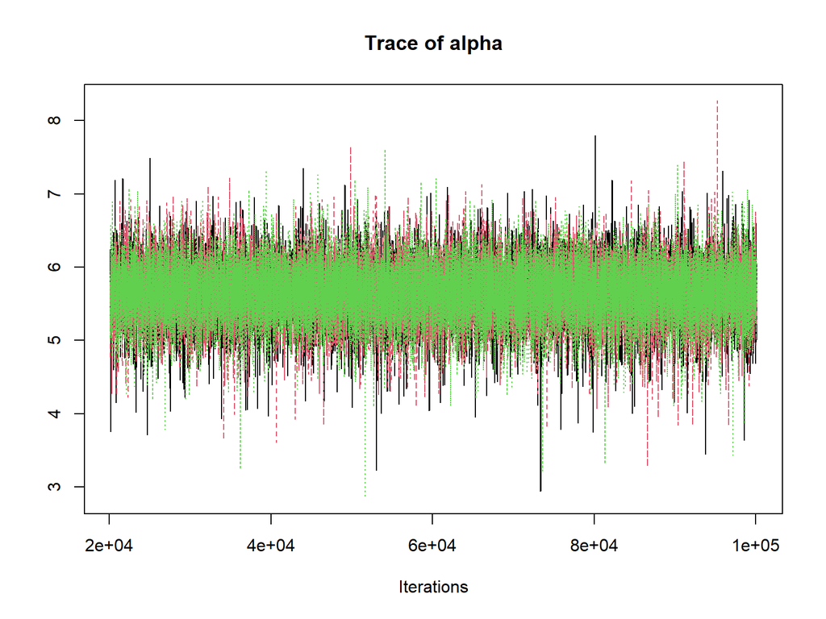

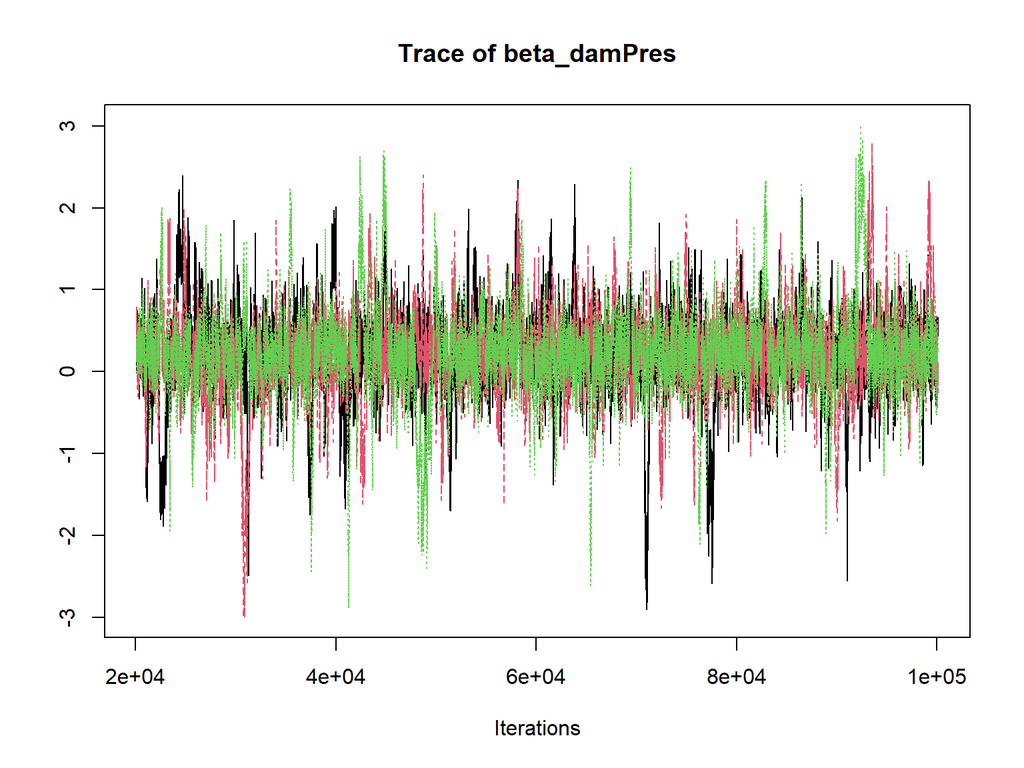

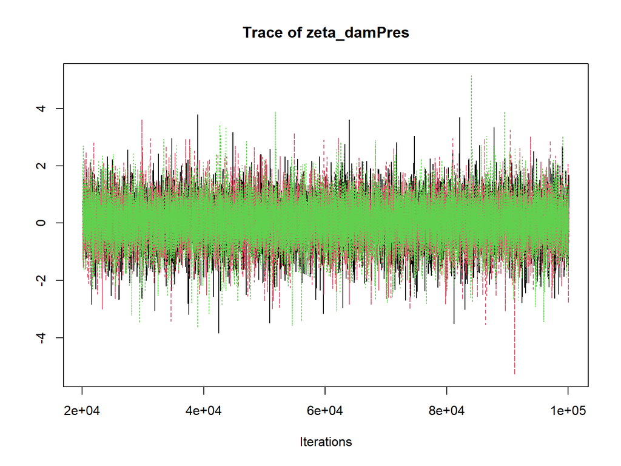

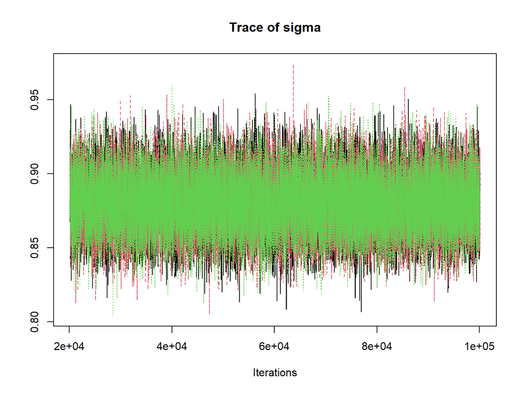

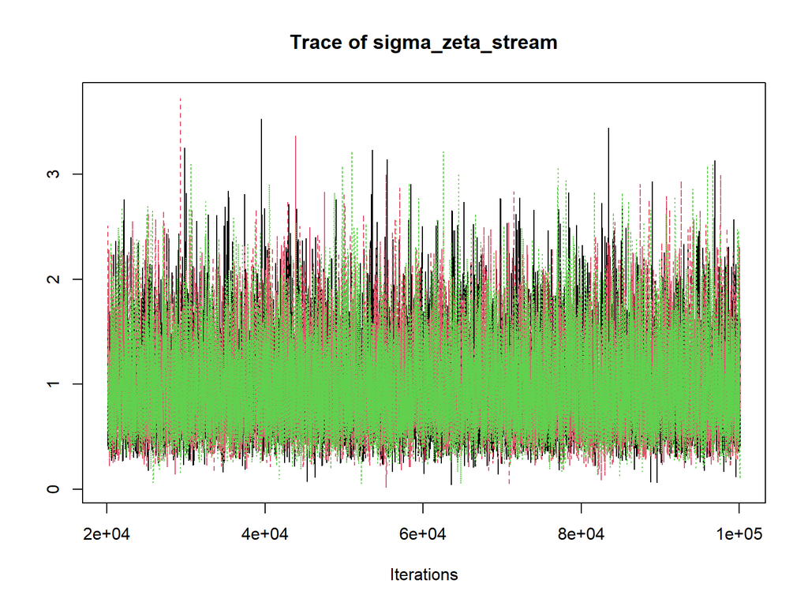

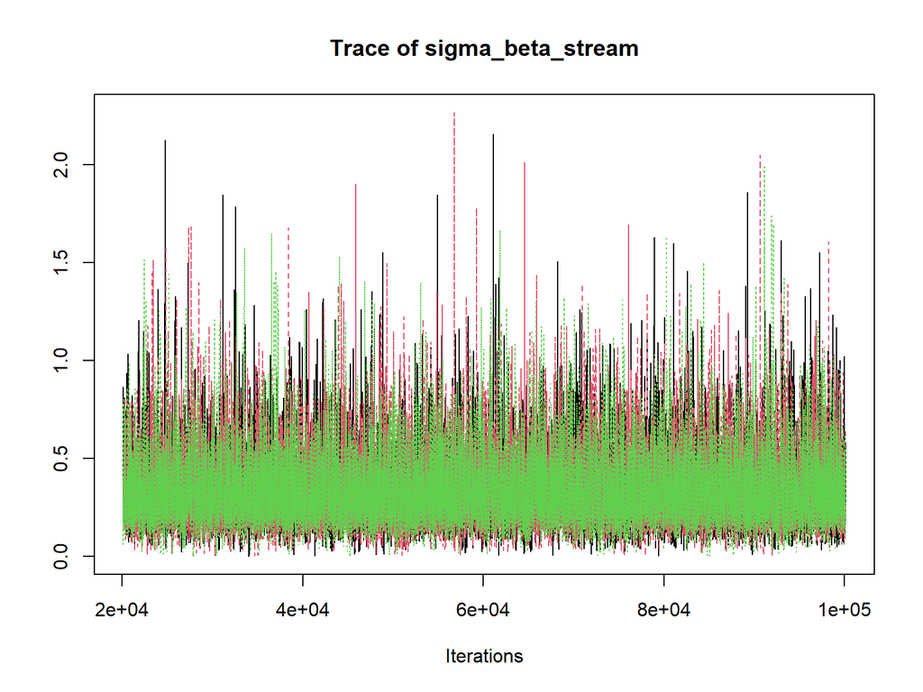

```
Traceplots are all mostly grassy. Again, see beta_damPres. Note: had to updated iterations, burnins, and thin rate to get convergence.
```

**Posterior predictive plots:**

Predicted Psi vs observed SW Presence

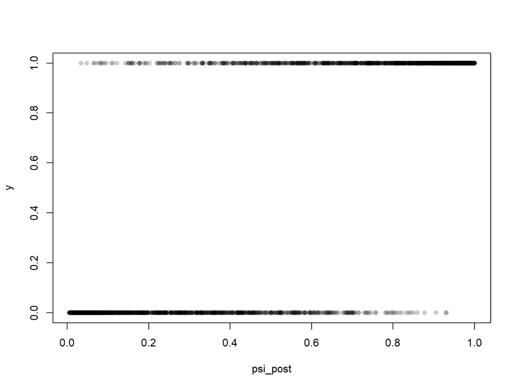

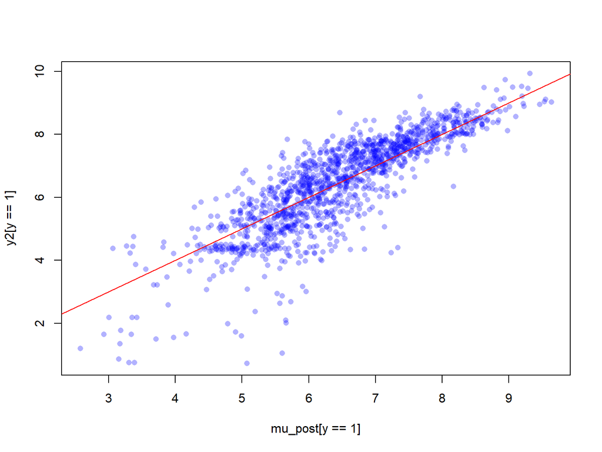

Random effects shrinkage:

goal is centered around 0(ish)

1. zeta_stream; random effect of stream on sw presence
2. beta_stream; random effect of stream on sw amount
3. zeta_event; random effect of sample event on sw presence
4. beta_event; random effect of sample event on sw amount

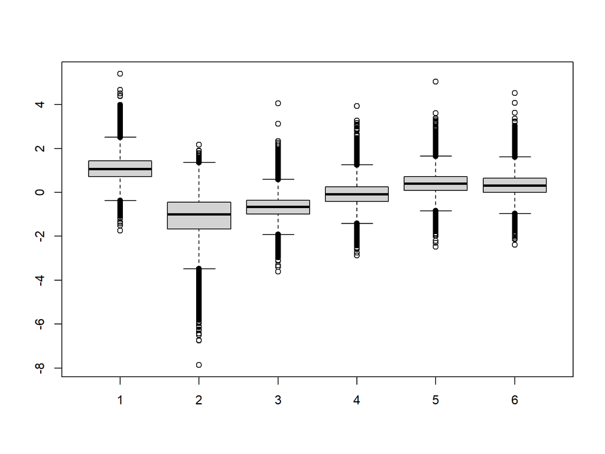

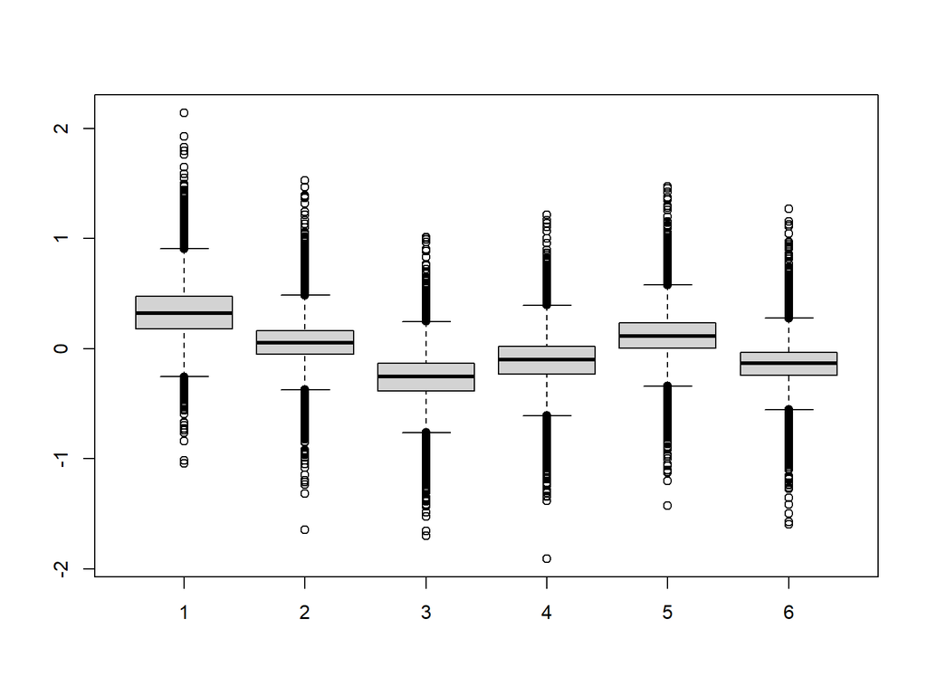

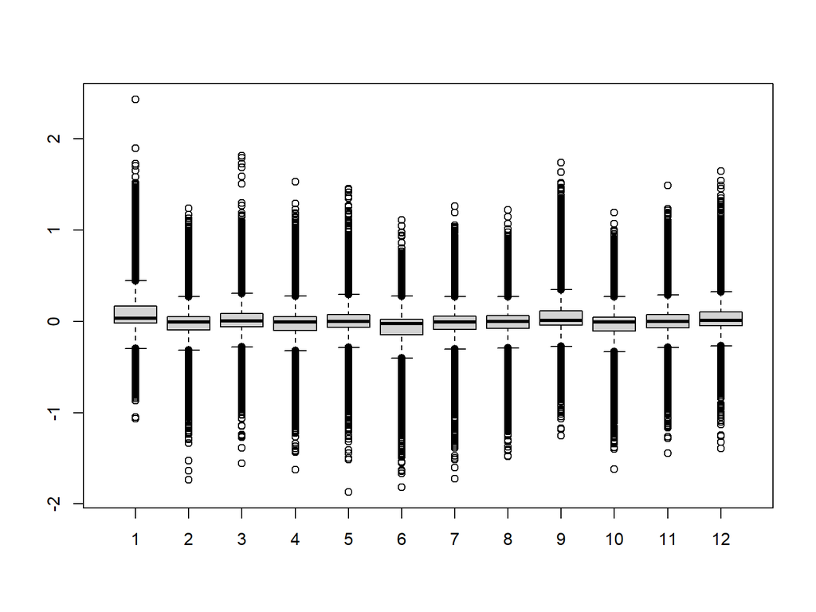

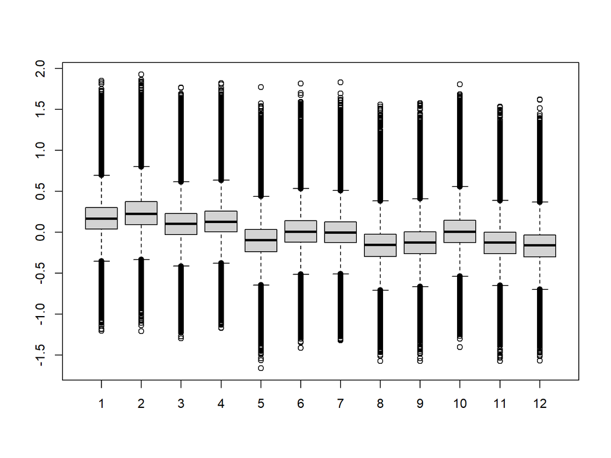

```
##    Min. 1st Qu.  Median    Mean 3rd Qu.    Max.
## 0.01933 0.67983 0.90720 0.97263 1.19511 3.72638
```

```
##      Min.   1st Qu.    Median      Mean   3rd Qu.      Max.
## 0.0002981 0.2085044 0.2916292 0.3303572 0.4066910 2.2682170
```

Check detection posteriors: goal is near empirical mean recall

```
##        V1               V2               V3               V4
##  Min.   :0.8862   Min.   :0.8903   Min.   :0.8797   Min.   :0.9159
##  1st Qu.:0.9849   1st Qu.:0.9838   1st Qu.:0.9859   1st Qu.:0.9899
##  Median :0.9924   Median :0.9918   Median :0.9929   Median :0.9950
##  Mean   :0.9892   Mean   :0.9884   Mean   :0.9899   Mean   :0.9928
##  3rd Qu.:0.9968   3rd Qu.:0.9966   3rd Qu.:0.9971   3rd Qu.:0.9979
##  Max.   :1.0000   Max.   :1.0000   Max.   :1.0000   Max.   :1.0000
##        V5               V6               V7               V8
##  Min.   :0.8278   Min.   :0.9071   Min.   :0.9168   Min.   :0.9151
##  1st Qu.:0.9718   1st Qu.:0.9888   1st Qu.:0.9907   1st Qu.:0.9888
##  Median :0.9856   Median :0.9944   Median :0.9953   Median :0.9944
##  Mean   :0.9799   Mean   :0.9920   Mean   :0.9933   Mean   :0.9920
##  3rd Qu.:0.9939   3rd Qu.:0.9976   3rd Qu.:0.9981   3rd Qu.:0.9977
##  Max.   :1.0000   Max.   :1.0000   Max.   :1.0000   Max.   :1.0000
##        V9              V10              V11              V12
##  Min.   :0.8428   Min.   :0.9142   Min.   :0.9102   Min.   :0.9073
##  1st Qu.:0.9765   1st Qu.:0.9898   1st Qu.:0.9870   1st Qu.:0.9875
##  Median :0.9881   Median :0.9948   Median :0.9935   Median :0.9938
##  Mean   :0.9831   Mean   :0.9927   Mean   :0.9907   Mean   :0.9911
##  3rd Qu.:0.9950   3rd Qu.:0.9979   3rd Qu.:0.9973   3rd Qu.:0.9974
##  Max.   :1.0000   Max.   :1.0000   Max.   :1.0000   Max.   :1.0000
```

```
##        V1                  V2                  V3
##  Min.   :1.731e-06   Min.   :6.850e-08   Min.   :1.002e-06
##  1st Qu.:5.214e-03   1st Qu.:5.088e-03   1st Qu.:5.350e-03
##  Median :8.321e-03   Median :8.161e-03   Median :8.470e-03
##  Mean   :8.546e-03   Mean   :8.405e-03   Mean   :8.699e-03
##  3rd Qu.:1.155e-02   3rd Qu.:1.140e-02   3rd Qu.:1.170e-02
##  Max.   :3.178e-02   Max.   :2.826e-02   Max.   :2.783e-02
##        V4                  V5                  V6
##  Min.   :1.303e-07   Min.   :8.195e-07   Min.   :3.377e-07
##  1st Qu.:6.133e-03   1st Qu.:4.891e-03   1st Qu.:4.320e-03
##  Median :9.310e-03   Median :7.934e-03   Median :7.287e-03
##  Mean   :9.485e-03   Mean   :8.191e-03   Mean   :7.596e-03
##  3rd Qu.:1.258e-02   3rd Qu.:1.111e-02   3rd Qu.:1.045e-02
##  Max.   :3.095e-02   Max.   :2.899e-02   Max.   :2.642e-02
##        V7                  V8                  V9
##  Min.   :1.023e-07   Min.   :3.012e-07   Min.   :1.021e-06
##  1st Qu.:4.786e-03   1st Qu.:4.357e-03   1st Qu.:5.735e-03
##  Median :7.839e-03   Median :7.274e-03   Median :8.888e-03
##  Mean   :8.117e-03   Mean   :7.615e-03   Mean   :9.091e-03
##  3rd Qu.:1.108e-02   3rd Qu.:1.044e-02   3rd Qu.:1.219e-02
##  Max.   :2.845e-02   Max.   :2.945e-02   Max.   :2.855e-02
##       V10                 V11                 V12
##  Min.   :2.090e-06   Min.   :7.010e-08   Min.   :1.628e-07
##  1st Qu.:4.999e-03   1st Qu.:5.231e-03   1st Qu.:4.610e-03
##  Median :8.094e-03   Median :8.255e-03   Median :7.581e-03
##  Mean   :8.349e-03   Mean   :8.527e-03   Mean   :7.872e-03
##  3rd Qu.:1.133e-02   3rd Qu.:1.153e-02   3rd Qu.:1.076e-02
##  Max.   :3.316e-02   Max.   :2.846e-02   Max.   :2.622e-02
```

```
TP is high and precise; FP is low and precise. This makes sense because these are based on empirical mean() and sd() recall and flase positive rates from the RF classifier (see multiprobability threshod validation).
```

Check z latent states

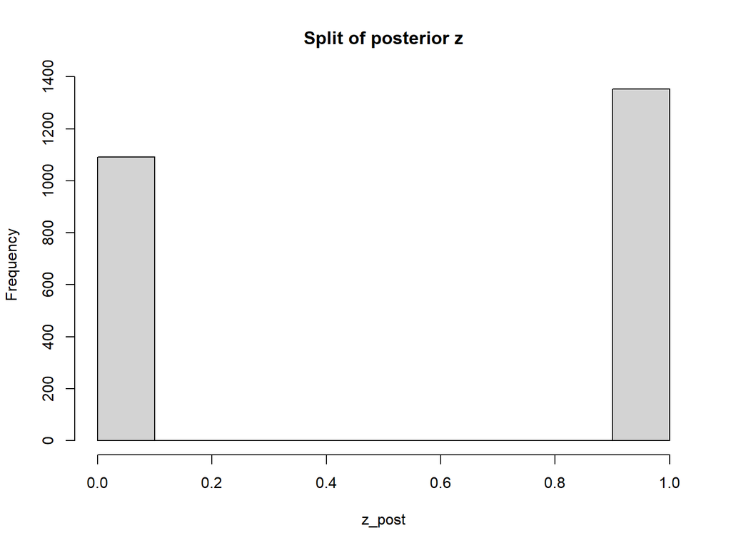

```
Latent z's split mostly evenly
```

Check tau_eff behavior:

[output not shown]

[output cut: 3613 more lines]

[output not shown]

[output not shown]

Check dam effects:

Posterior mean dam effects:

damPres -> swPres

```
##     Min.  1st Qu.   Median     Mean  3rd Qu.     Max.
## -5.29316 -0.31540  0.08098  0.06293  0.45937  5.15488
```

```
## [1] 1.064949
```

[output not shown]

damPres -> swAmount

```
##      Min.   1st Qu.    Median      Mean   3rd Qu.      Max.
## -3.003629 -0.004338  0.220826  0.211275  0.444433  3.019540
```

```
## [1] 1.235252
```

[output not shown]

## —-

Prior-posterior overlap:

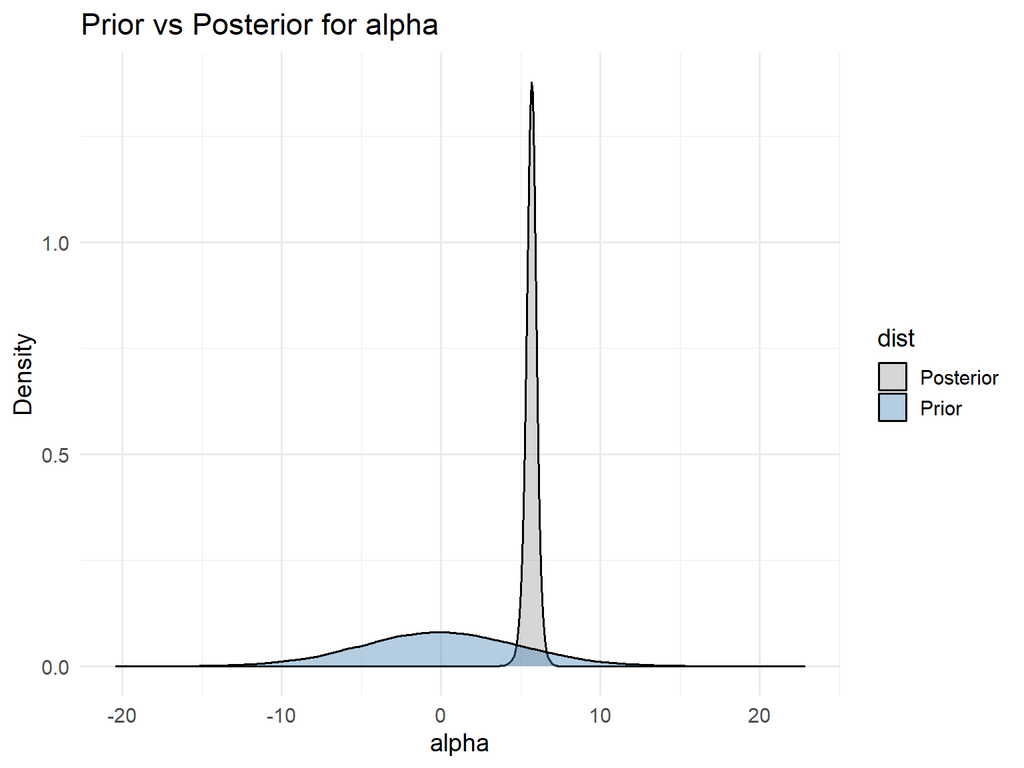

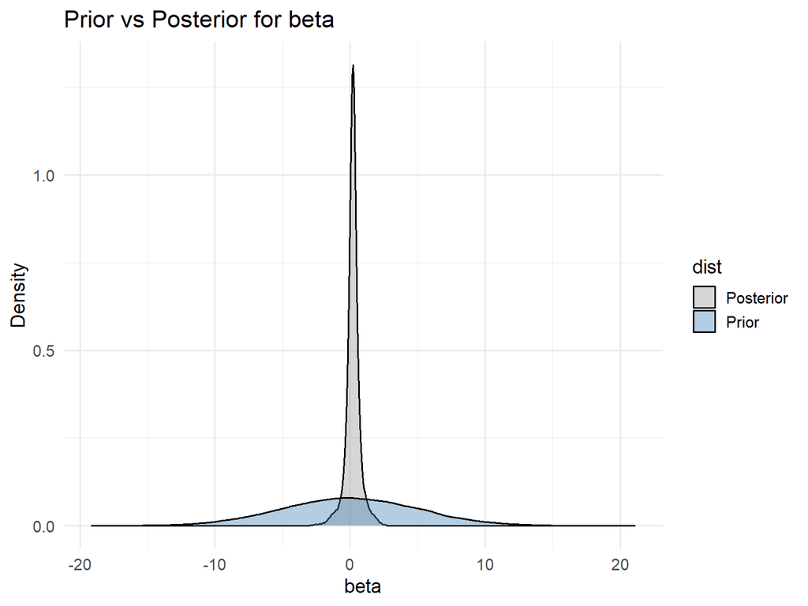

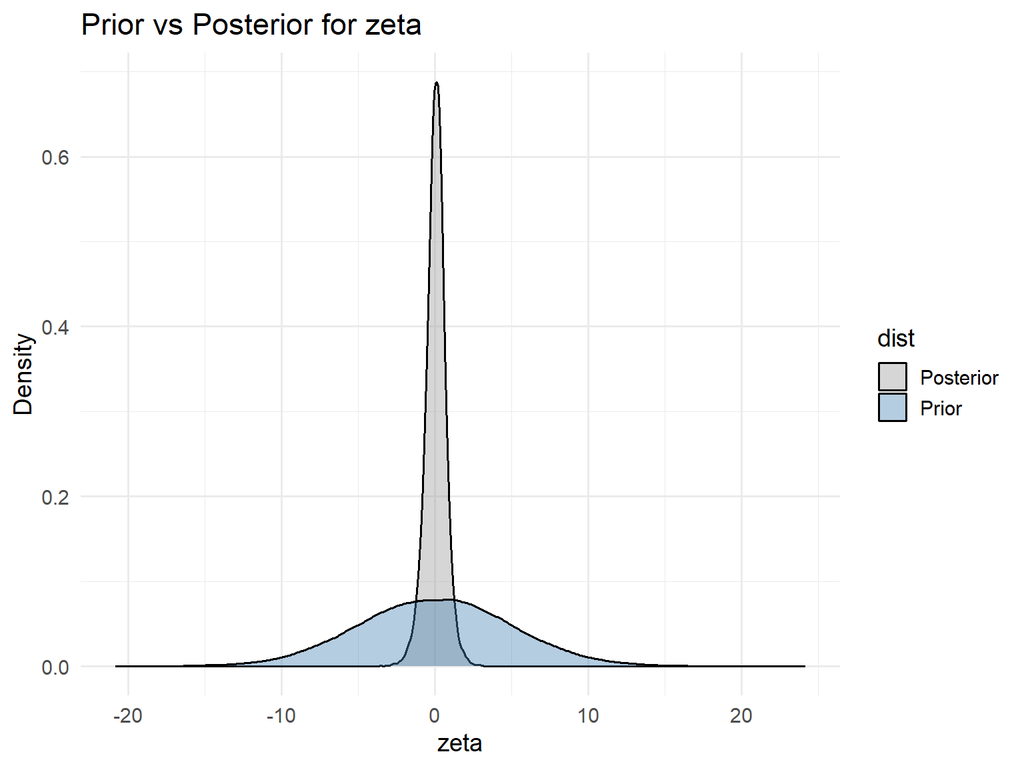

## —-

Marginal effect of dam presence on surface water presence, given geomorphic context

**Note** there’s a TINY positive effect of dam presence on surface water presence. Not really perceptible from these plots.

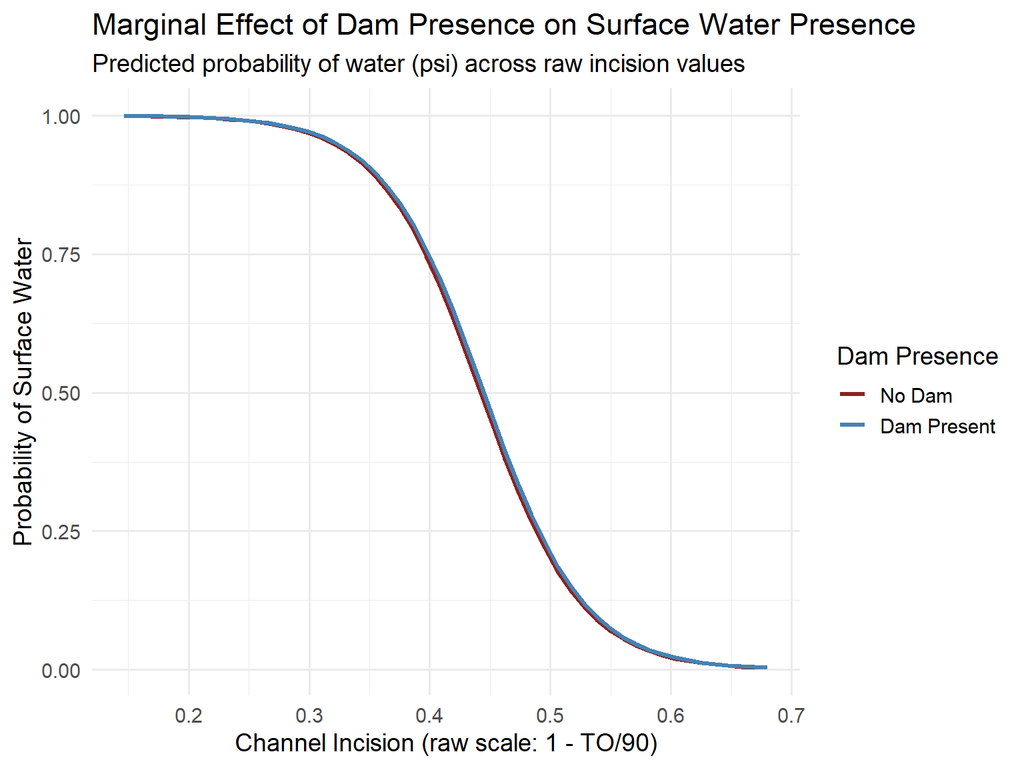

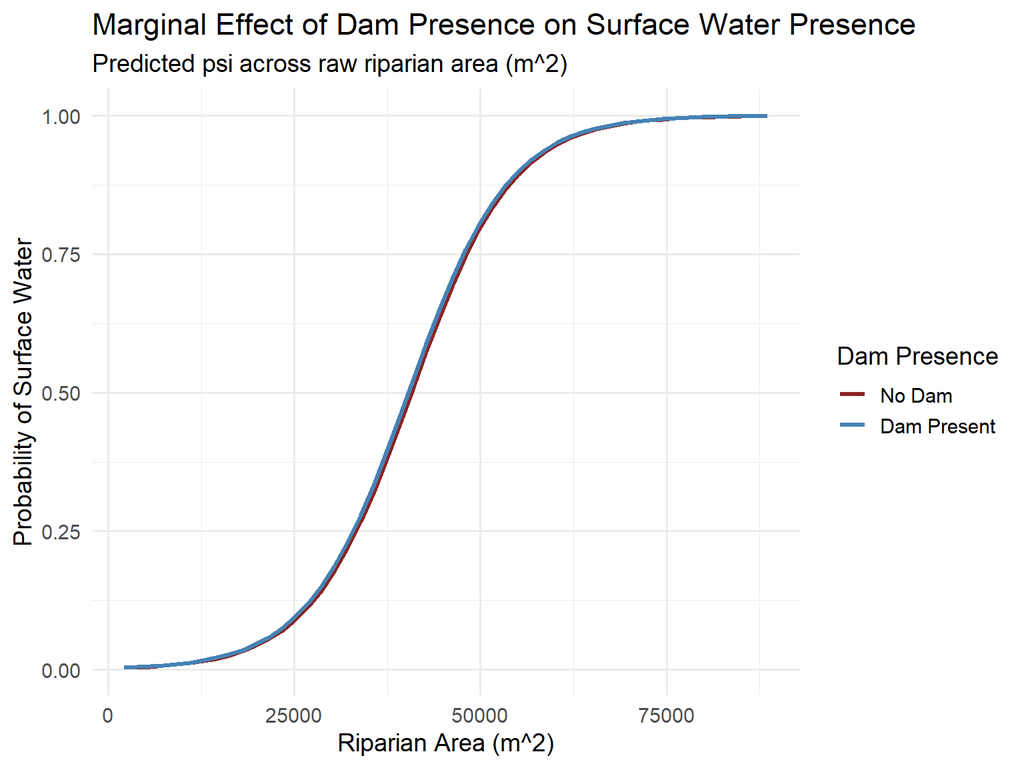

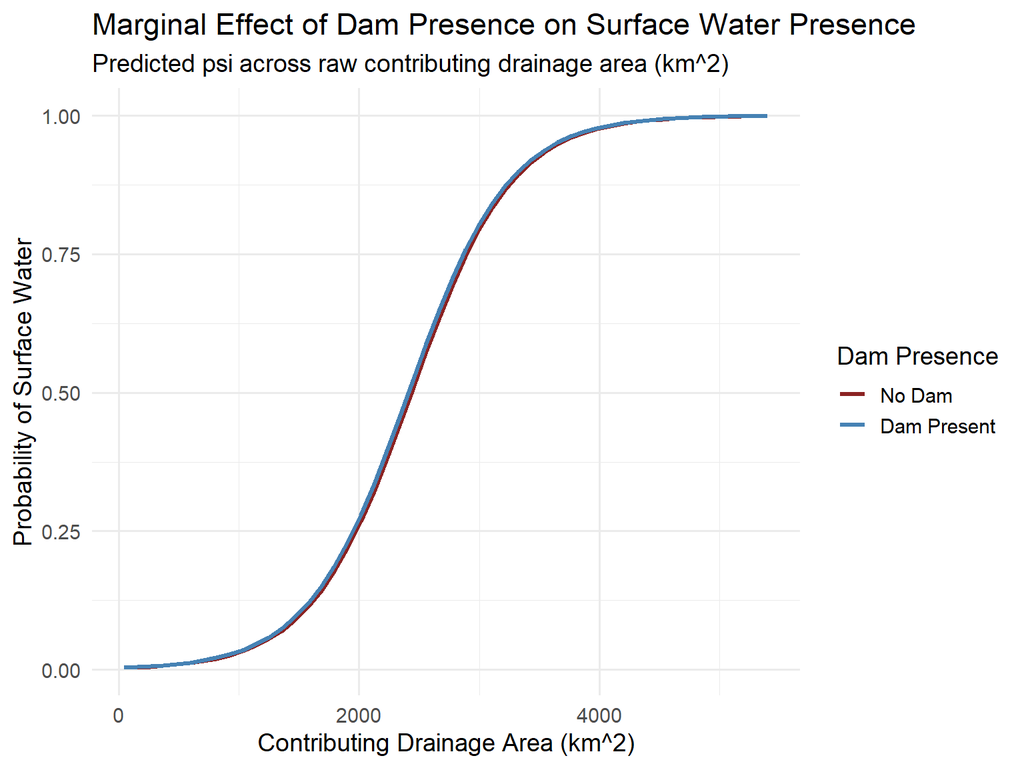

Partial dependence plots

Constrain PDP to empirical ranges for SWA and target covariates

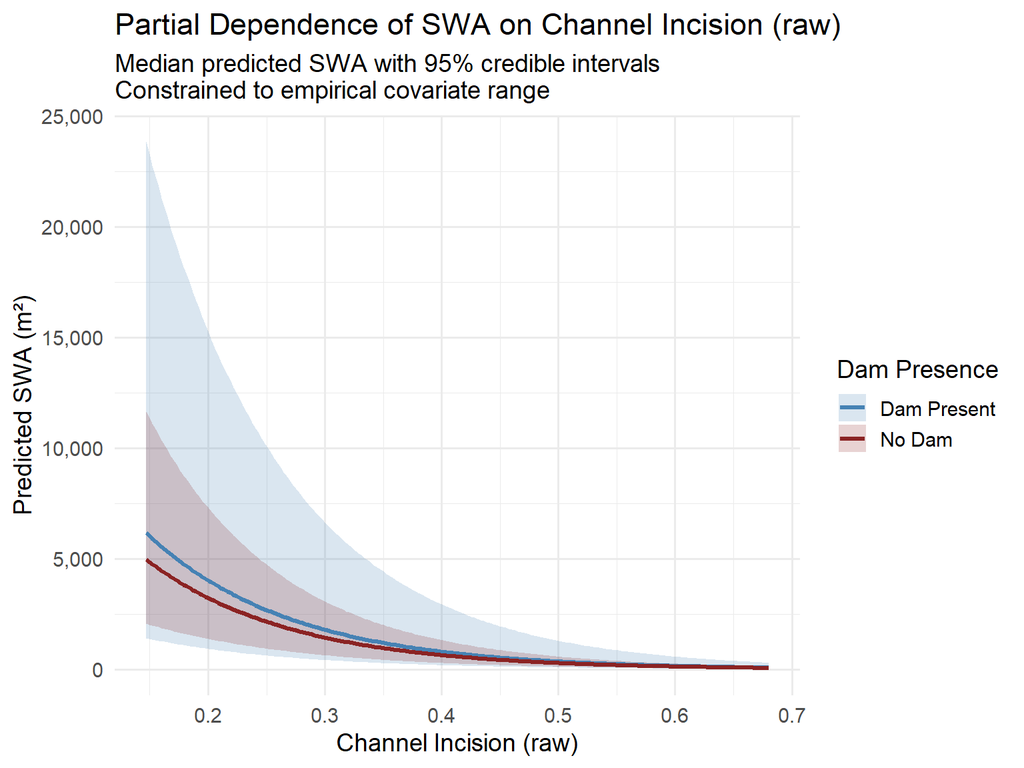

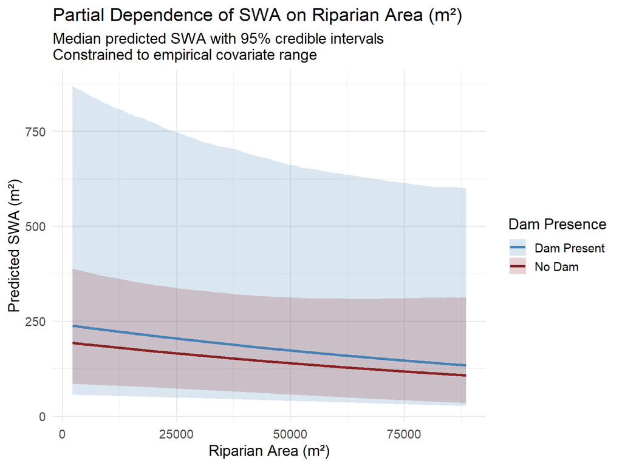

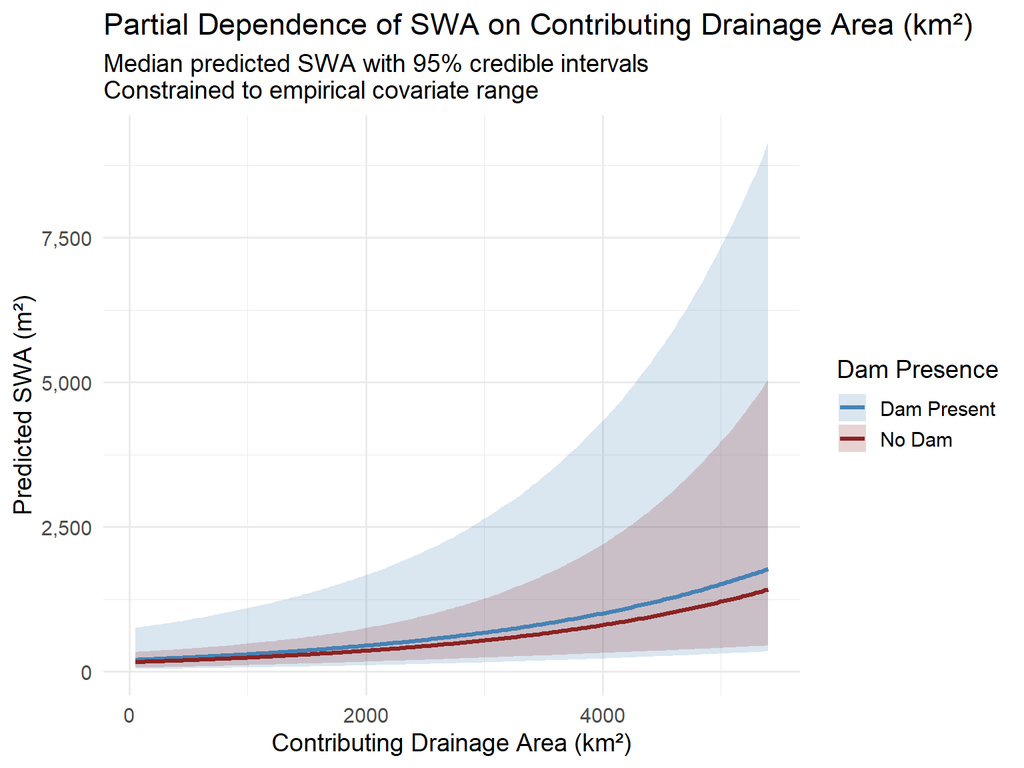

## —-

## Dam Density

## **Hurdle HGLMM**

```
sink("HGLMM_hurdle_damDensity.jags")

cat("
model{
  # NEED priors and hyperpriors first so that downstream nodes can be estimated

  ##########################################################################

  # HYPERPRIORS FOR SW PRESENCE (1/2 Normal on SDs):

  sigma_zeta_stream  ~ dnorm(0,1) T(0,)
  tau_zeta_stream    <- pow(sigma_zeta_stream, -2)

  sigma_zeta_year    ~ dnorm(0,1) T(0,)
  tau_zeta_year      <- pow(sigma_zeta_year, -2)

  sigma_zeta_event   ~ dnorm(0,1) T(0,)
  tau_zeta_event     <- pow(sigma_zeta_event, -2)

  sigma_iota_stream  ~ dnorm(0,1) T(0,)
  tau_iota_stream    <- pow(sigma_iota_stream, -2)

  sigma_iota_event   ~ dnorm(0,1) T(0,)
  tau_iota_event     <- pow(sigma_iota_event, -2)

  sigma_iota_cluster ~ dnorm(0,1) T(0,)
  tau_iota_cluster   <- pow(sigma_iota_cluster, -2)

  ##########################################################################
  # HYPERPRIORS FOR SW AMOUNT (1/2 Normal on SDs):

  sigma              ~ dnorm(0,1) T(0,)
  tau                <- pow(sigma, -2)

  sigma_beta_stream  ~ dnorm(0, 0.7) T(0,)
  tau_beta_stream    <- pow(sigma_beta_stream, -2)

  sigma_beta_year    ~ dnorm(0, 0.7) T(0,)
  tau_beta_year      <- pow(sigma_beta_year, -2)

```

[output cut: 111 more lines]

```
                  + beta_event[event[i]]) * damDen[i]
                + beta_incis * incis[i]
                + beta_RIPA * RIPA[i]
                + beta_UDA * UDA[i]
                + eta_stream[stream[i]]
                + eta_event[event[i]]
                + eta_cluster[cluster[i]])

    tau_eff[i] <- z[i] * tau + (1 - z[i]) * 100
  }

}
", fill = TRUE)

sink()
```

```
##
## Processing function input.......
##
## Done.
##
## Beginning parallel processing using 3 cores. Console output will be suppressed.
##
## Parallel processing completed.
##
## Calculating statistics.......
##
## Done.
```

```
## [1] "2026-07-24 16:19:43 MDT"
```

## —-

DIAGNOSTICS:

Extract posteriors:

“Chain health” Rhat + ESS:

```
## Potential scale reduction factors:
##
##                    Point est. Upper C.I.
## epsilon                  1.00       1.00
## alpha                    1.00       1.00
## zeta_damDen              1.00       1.00
## beta_damDen              1.04       1.05
## zeta_incis               1.00       1.00
## beta_incis               1.00       1.00
## zeta_RIPA                1.00       1.00
## beta_RIPA                1.00       1.00
## zeta_UDA                 1.00       1.00
## beta_UDA                 1.00       1.00
## sigma                    1.00       1.00
## sigma_zeta_stream        1.00       1.00
## sigma_iota_cluster       1.00       1.00
## p_TP[1]                  1.00       1.00
## p_FP[1]                  1.00       1.00
```

```
##            epsilon              alpha        zeta_damDen        beta_damDen
##          37786.268          48000.000          37550.995           1092.429
##         zeta_incis         beta_incis          zeta_RIPA          beta_RIPA
##          18874.835          44572.703          46517.897          48000.000
##           zeta_UDA           beta_UDA              sigma  sigma_zeta_stream
##          17970.169          47091.078          45798.111          10148.996
## sigma_iota_cluster            p_TP[1]            p_FP[1]
##           8879.839          36722.890          48265.974
```

[output not shown]

Check traceplots for critical parameters

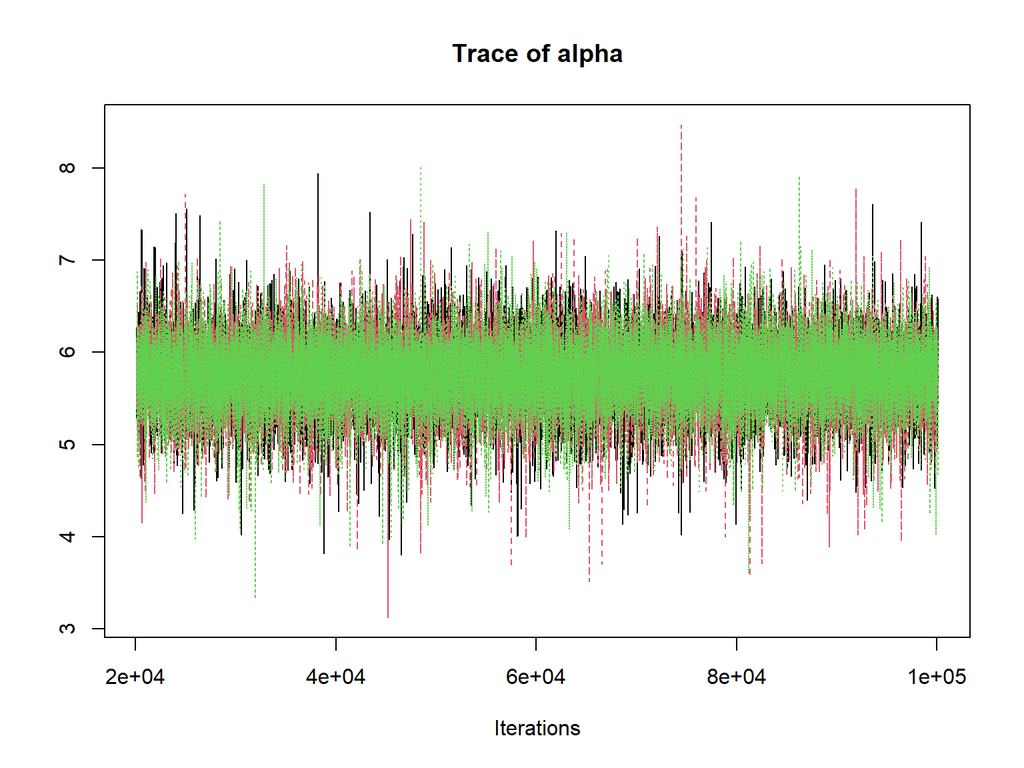

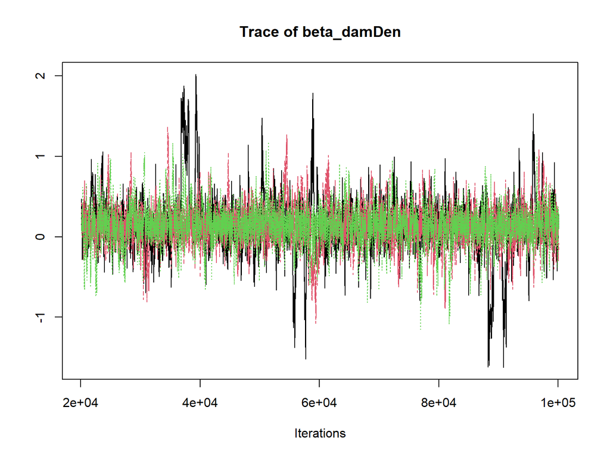

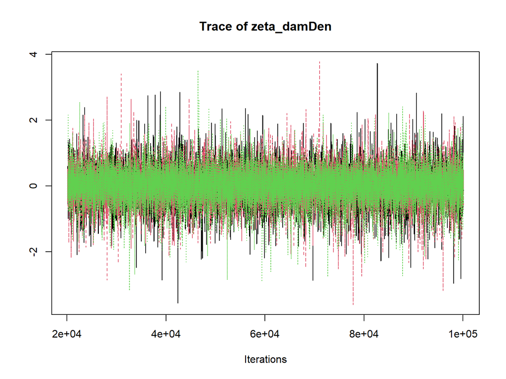

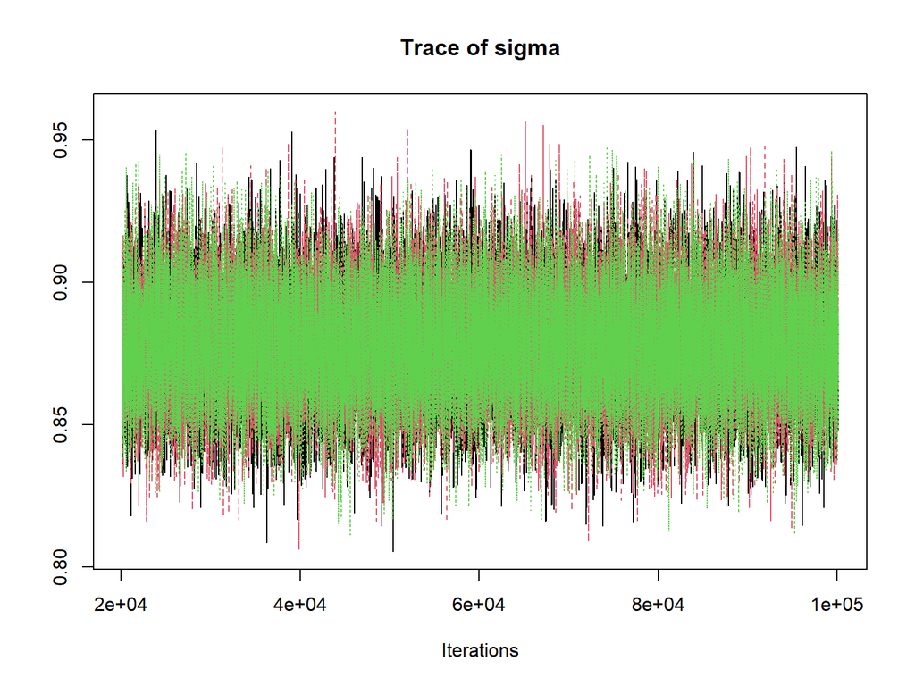

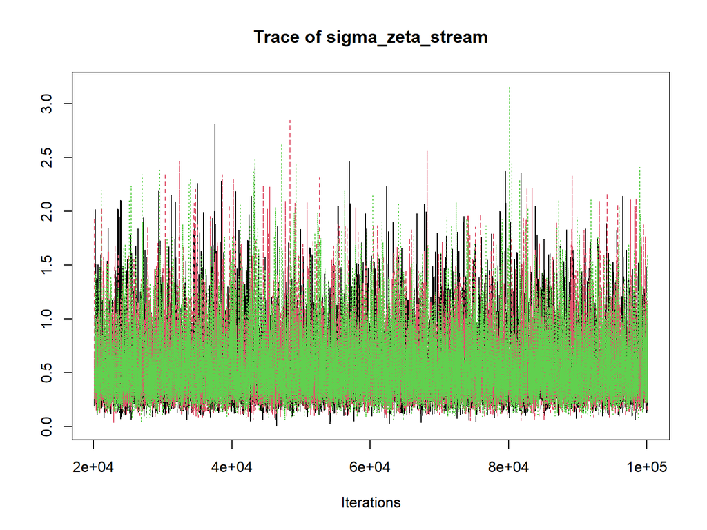

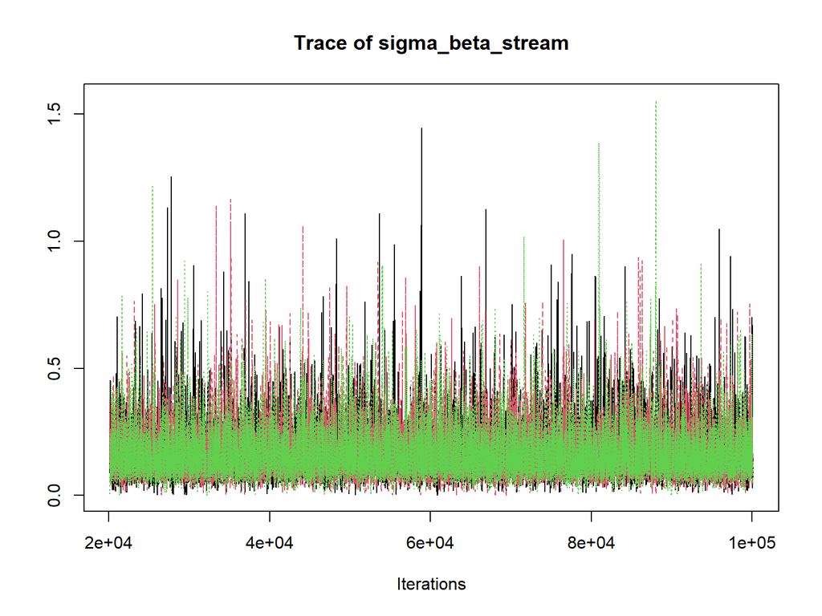

```
Traceplots all look good, except for beta_damDen, which is mostly grassy, but
slow to converge - suggesting that its difficult for the model to estimate.
```

Posterior predictive plots:

Predicted SW vs observed SW

Goal is 1:1 (ish)

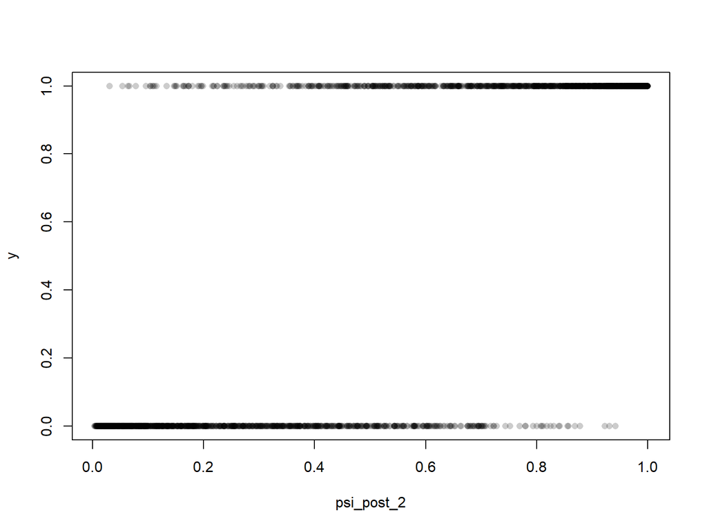

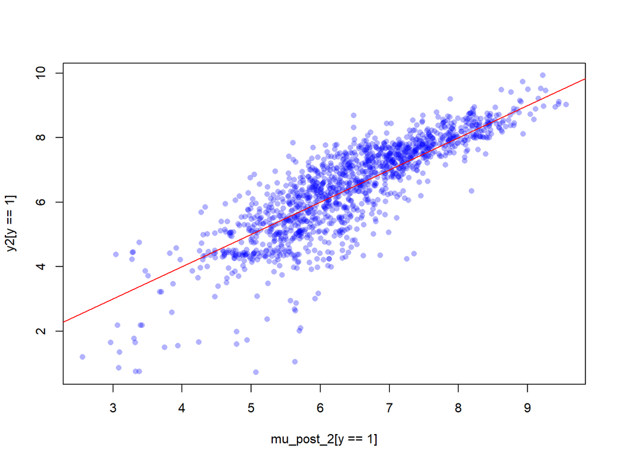

Random effects shrinkage:

goal is centered around 0(ish)

1. zeta_stream; random effect of stream on sw presence
2. beta_stream; random effect of stream on sw amount
3. zeta_event; random effect of sample event on sw presence
4. beta_event; random effect of sample event on sw amount

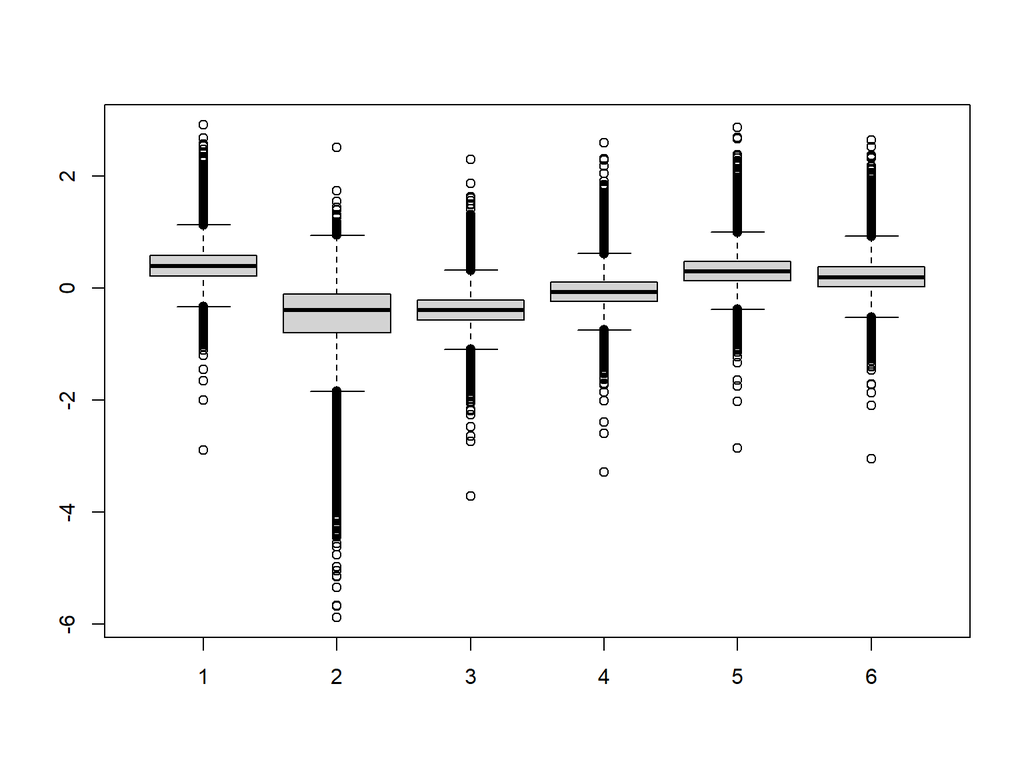

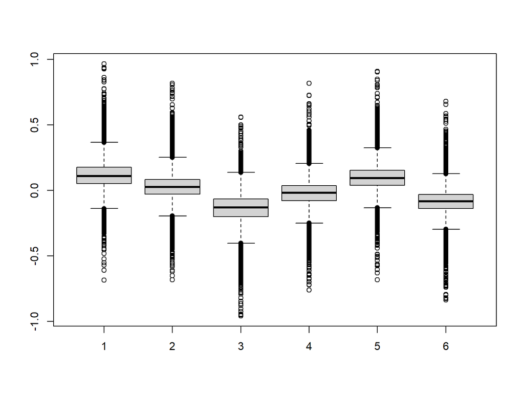

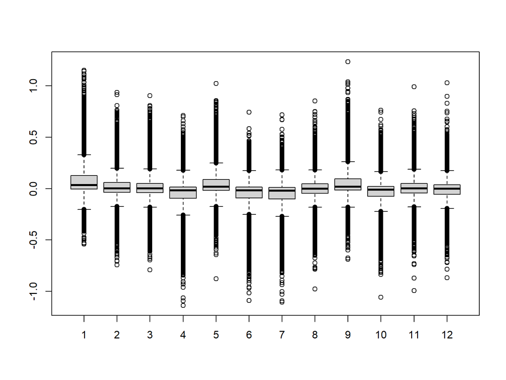

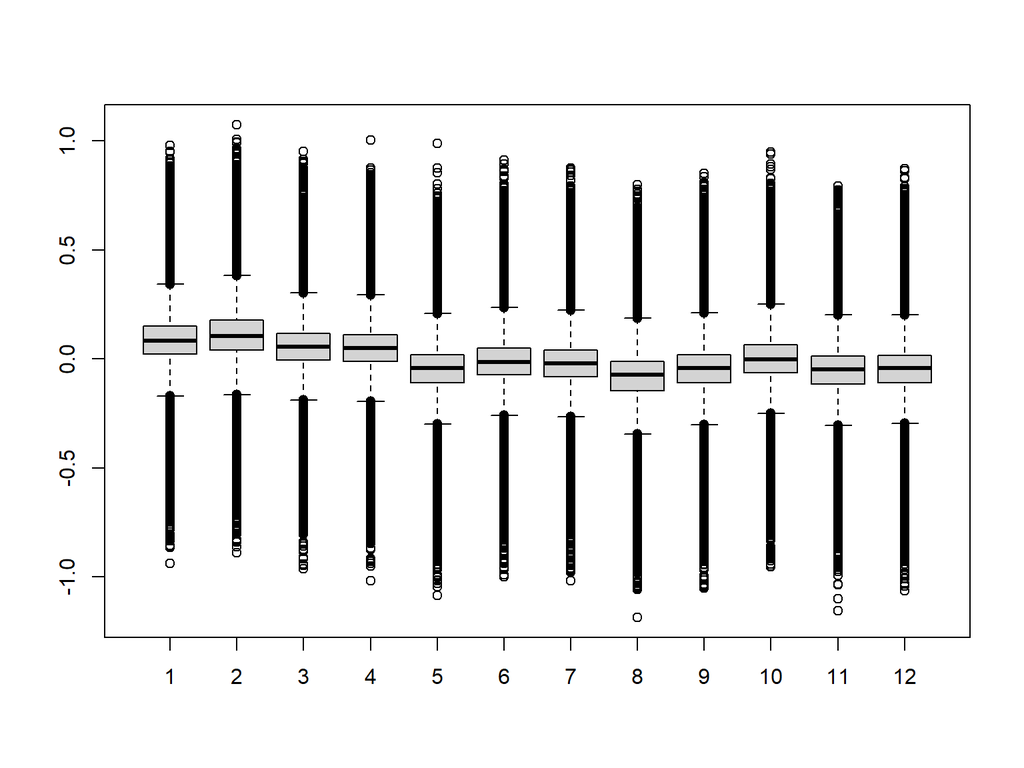

## —-

## —-

Posterior mean dam effects:

damDen -> swPres

```
##     Min.  1st Qu.   Median     Mean  3rd Qu.     Max.
## -3.61289 -0.20362  0.04448  0.02873  0.27554  3.78840
```

```
## [1] 1.02915
```

[output not shown]

damDen -> swAmount

```
##     Min.  1st Qu.   Median     Mean  3rd Qu.     Max.
## -1.62519  0.03025  0.14084  0.14223  0.25265  2.02211
```

```
## [1] 1.152846
```

[output not shown]

## —-

Prior-posterior overlap:

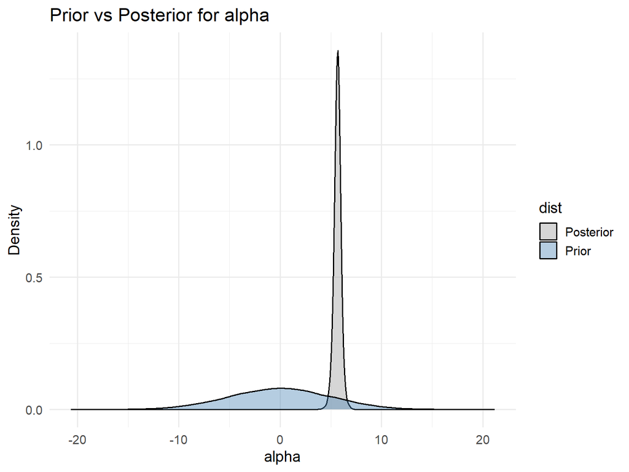

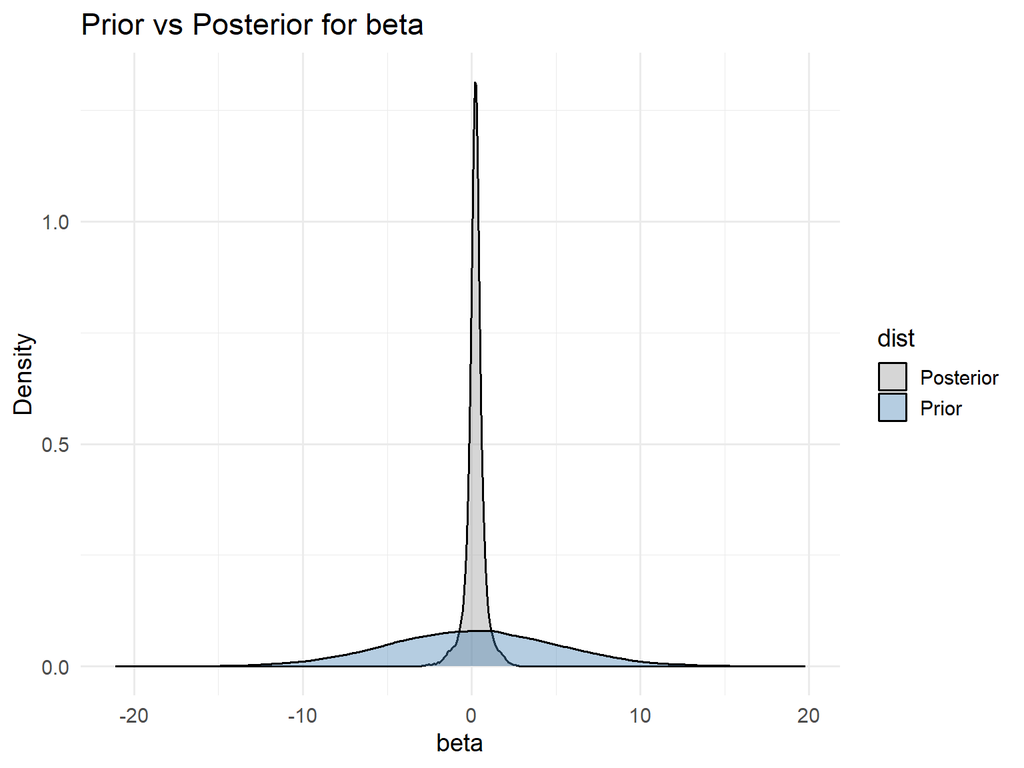

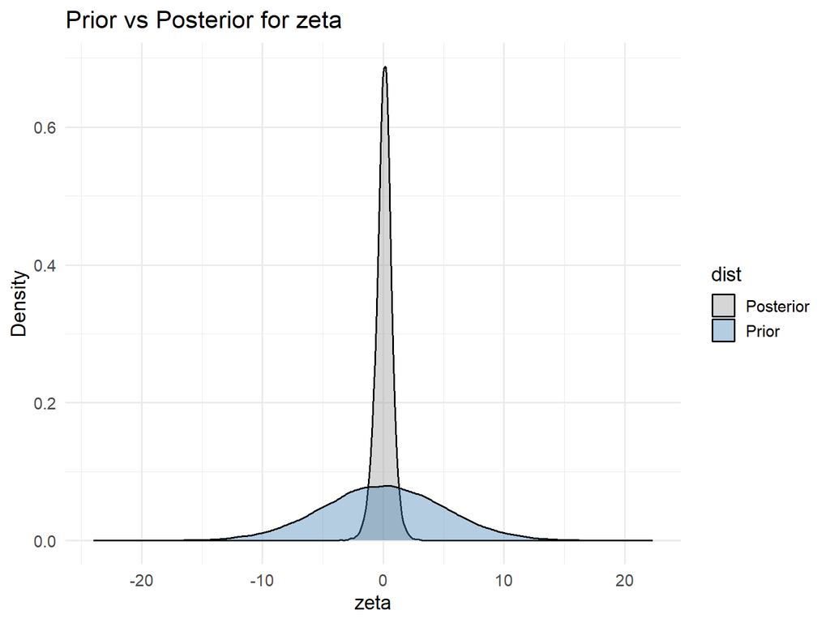

## —-

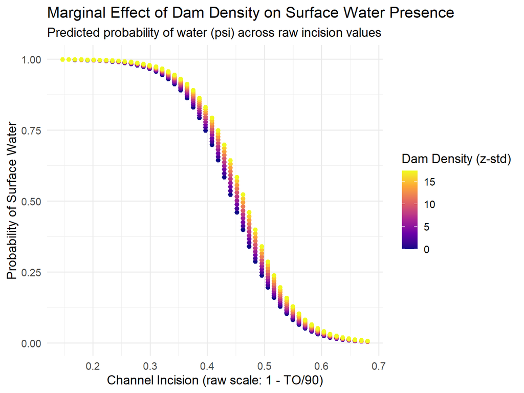

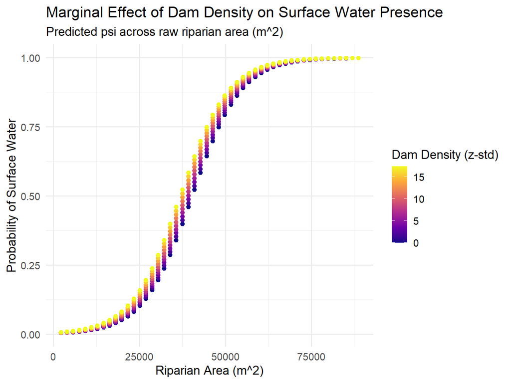

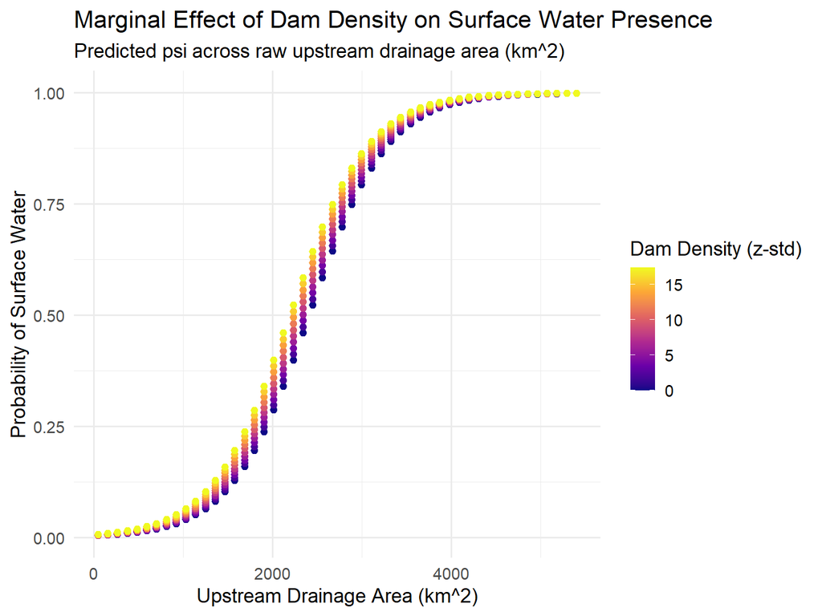

Partial dependence plots

Constrain PDP to empirical ranges for SWA and target covariates

[figure not shown]

[figure not shown]

[figure not shown]